# Praca Domowa 7

Autor: Paulina Przybyłek

## Wczytanie danych i odpowiednich pakietów

```python
from skimage import io
import matplotlib.pyplot as plt
import numpy as np
from sklearn.decomposition import PCA

import warnings
warnings.filterwarnings('ignore')
```

Wczytajmy obrazek z kotkiem. Jest to kolorowy obrazek zapisany jako plik `.jpg`. Poniżej możemy zobaczyć jak wygląda rzeczywiście.

```python
image = io.imread('kotek.jpg')
print(image[0:2])
```

```
[[[232 230 218]
  [232 230 218]
  [232 230 218]
  ...
  [251 248 241]
  [252 249 242]
  [252 249 242]]

 [[232 230 218]
  [232 230 218]
  [232 230 218]
  ...
  [251 248 241]
  [252 249 242]
  [252 249 242]]]
```

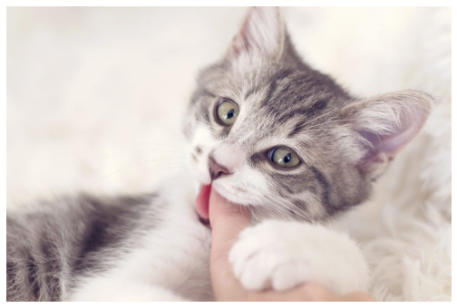

```python
def plot_image(image):
    """
    Zwraca obrazek podany jako argument w postaci macierzy.
    """
    plt.figure(figsize=(12, 6))
    plt.imshow(image)
    plt.axis('off')
    plt.show()

plot_image(image)
```

Ciekawy może nie jest, ale walorem jest uroczy i ładny kotek (szczególnie jak ktoś lubi koty ^^).

## Redukcja wymiarów - PCA

Przyjrzyjmy się wymiarom wczytanego obrazka zanim przejdziemy do redukcji wymiarów.

```python
image.shape
```

```
(575, 864, 3)
```

```python
# musimy zrobić obrazek 2D
image_2D = np.reshape(image, (575, 864*3))
print("Wymiary naszego obrazka: ", image_2D.shape)
```

```
Wymiary naszego obrazka:  (575, 2592)
```

Spróbujmy na takim obrazku wykonać PCA - korzystając z implementacji sklearn. Tylko jak ustawić parametry? Spróbujemy `svd_solver = "randomized"` przy ustawionym ziarnie na $0$ a następnie znajdziemy odpowiednią liczbę komponentów do PCA.

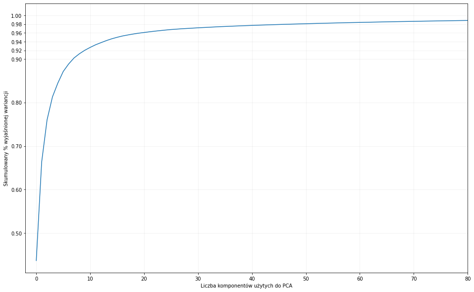

```python
pca = PCA(svd_solver="randomized", random_state=0).fit(image_2D)

plt.figure(figsize=(16,10))
plt.plot(np.cumsum(pca.explained_variance_ratio_)) # skumulowany procent wyjaśnionej wariancji
plt.xlim(-2,80) # dalej nie wzrasta zbytnio
plt.grid(alpha=0.2)
plt.yticks([0.5, 0.6, 0.7, 0.8, 0.9, 0.92, 0.94, 0.96, 0.98, 1.0])
plt.xlabel('Liczba komponentów użytych do PCA')
plt.ylabel('Skumulowany % wyjaśnionej wariancji')
plt.show()
```

Dla $80$ komponentów uzyskujemy niemal $99\%$ wariancji. I tak znacznie zmniejszymy wymiary, więc zobaczmy jak to wygląda.

```python
def image_pca(components):
    """
    Funkcja wykonuje PCA na obrazku dla podanej liczby komponentów.
    """
    image_pca = PCA(n_components = components, svd_solver="randomized", random_state=0).fit(image_2D)
    image_reduced = image_pca.transform(image_2D)
    print("Wymiary po redukcji: ", image_reduced.shape)
    print("Procent wyjaśnionej wariancji: ", np.sum(image_pca.explained_variance_ratio_))
    image_reduced = image_pca.inverse_transform(image_reduced)
    return image_reduced

image_reduced = image_pca(80)
```

```
Wymiary po redukcji:  (575, 80)
Procent wyjaśnionej wariancji:  0.988552358252875
```

```python
# wróćmy do obrazka z 3 kanałami
image_converted = np.reshape(image_reduced, (575,864,3))
```

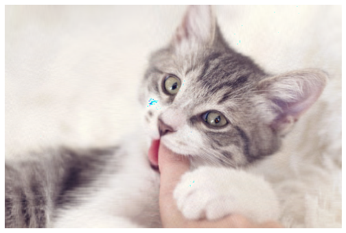

```python
plot_image((image_converted).astype(np.uint8))
```

Mimo dużego procentu wariancji kotek stracił na jakości. Jednak pamiętajmy, że wzięliśmy $80$ kompentów z $2592$, więc zmniejszyliśmy objętość $32,4$. Spróbujmy zrobić to dla większej liczby i zobaczmy jak będzie to wyglądać. Co ważne już teraz poza czterema miejscami obraz odtworzył się idealnie, więc wiele nie brakuje.

```
Wymiary po redukcji:  (575, 360)
Procent wyjaśnionej wariancji:  0.9999130496142241
```

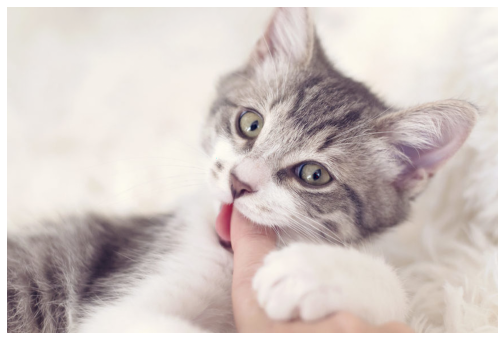

```python
image_reduced = image_pca(360)
image_converted = np.reshape(image_reduced, (575,864,3))
plot_image((image_converted).astype(np.uint8))
```

Dla $360$ komponentach kotek jest prawie idealny. Ja sama widzę przebarwienie w jednym miejscu - na policzku jest mała kropka. Jednak mamy zmniejszony wymiar $7.2$ razy a efekt jest niesamowity, jakość obrazka jest niemal zachowana. Można to uznać za sukces.